# Summaries

2019-03-21

```r
library(tidyverse)
library(nycflights13)
```

dplyr summarise() function can be used to calculate counts and proportions of logical values: sum(x > 10), mean(y == 0).

When used with numeric functions, TRUE is converted to 1 and FALSE to 0.

> This makes sum() and mean() very useful: sum(x) gives the number of TRUEs in x, and mean(x) gives the proportion.

### Exercises

1. Using nycflights13 “flights” dataset, brainstorm at least 5 different ways to assess the typical delay characteristics of a group of flights.

```r
flights
```

```
## # A tibble: 336,776 x 19
##     year month   day dep_time sched_dep_time dep_delay arr_time
##    <int> <int> <int>    <int>          <int>     <dbl>    <int>
##  1  2013     1     1      517            515         2      830
##  2  2013     1     1      533            529         4      850
##  3  2013     1     1      542            540         2      923
##  4  2013     1     1      544            545        -1     1004
##  5  2013     1     1      554            600        -6      812
##  6  2013     1     1      554            558        -4      740
##  7  2013     1     1      555            600        -5      913
##  8  2013     1     1      557            600        -3      709
##  9  2013     1     1      557            600        -3      838
## 10  2013     1     1      558            600        -2      753
## # … with 336,766 more rows, and 12 more variables: sched_arr_time <int>,
## #   arr_delay <dbl>, carrier <chr>, flight <int>, tailnum <chr>,
## #   origin <chr>, dest <chr>, air_time <dbl>, distance <dbl>, hour <dbl>,
## #   minute <dbl>, time_hour <dttm>
```

```r
select(flights, flight, dep_time,dep_delay)
```

```
## # A tibble: 336,776 x 3
##    flight dep_time dep_delay
##     <int>    <int>     <dbl>
##  1   1545      517         2
##  2   1714      533         4
##  3   1141      542         2
##  4    725      544        -1
##  5    461      554        -6
##  6   1696      554        -4
##  7    507      555        -5
##  8   5708      557        -3
##  9     79      557        -3
## 10    301      558        -2
## # … with 336,766 more rows
```

```r
select(flights, flight, arr_time, arr_delay)
```

```
## # A tibble: 336,776 x 3
##    flight arr_time arr_delay
##     <int>    <int>     <dbl>
##  1   1545      830        11
##  2   1714      850        20
##  3   1141      923        33
##  4    725     1004       -18
##  5    461      812       -25
##  6   1696      740        12
##  7    507      913        19
##  8   5708      709       -14
##  9     79      838        -8
## 10    301      753         8
## # … with 336,766 more rows
```

```r
select(flights, flight, dep_time, sched_dep_time)
```

```
## # A tibble: 336,776 x 3
##    flight dep_time sched_dep_time
##     <int>    <int>          <int>
##  1   1545      517            515
##  2   1714      533            529
##  3   1141      542            540
##  4    725      544            545
##  5    461      554            600
##  6   1696      554            558
##  7    507      555            600
##  8   5708      557            600
##  9     79      557            600
## 10    301      558            600
## # … with 336,766 more rows
```

```r
select(flights, flight, arr_time, sched_arr_time)
```

```
## # A tibble: 336,776 x 3
##    flight arr_time sched_arr_time
##     <int>    <int>          <int>
##  1   1545      830            819
##  2   1714      850            830
##  3   1141      923            850
##  4    725     1004           1022
##  5    461      812            837
##  6   1696      740            728
##  7    507      913            854
##  8   5708      709            723
##  9     79      838            846
## 10    301      753            745
## # … with 336,766 more rows
```

Consider the following scenarios:

- A flight is 15 minutes early 50% of the time, and 15 minutes late 50% of the time.

```r
flights %>%
  group_by(flight) %>%
  summarize(early15 = sum(arr_delay <= -15, na.rm = TRUE)/ n(),
            late15 = sum(arr_delay >= 15, na.rm = TRUE)/ n(),
            n = n()) %>%
  filter(early15 == 0.5,
         late15 == 0.5)
```

```
## # A tibble: 18 x 4
##    flight early15 late15     n
##     <int>   <dbl>  <dbl> <int>
##  1    107     0.5    0.5     2
##  2   2072     0.5    0.5     2
##  3   2366     0.5    0.5     2
##  4   2500     0.5    0.5     2
##  5   2552     0.5    0.5     2
##  6   3495     0.5    0.5     2
##  7   3518     0.5    0.5     2
##  8   3544     0.5    0.5     2
##  9   3651     0.5    0.5     2
## 10   3705     0.5    0.5     2
## 11   3916     0.5    0.5     2
## 12   3951     0.5    0.5     2
## 13   4273     0.5    0.5     2
## 14   4313     0.5    0.5     2
## 15   5297     0.5    0.5     2
## 16   5322     0.5    0.5     2
## 17   5388     0.5    0.5     2
## 18   5505     0.5    0.5     4
```

- A flight is always 10 minutes late.

```r
flights %>%
  group_by(flight) %>%
  summarise(late10per = n_distinct(arr_delay, na.rm = TRUE) / n(),
            min10 = mean(arr_delay, na.rm = TRUE),
            n = n()) %>%
  filter(late10per == 1 & min10 == 10)
```

```
## # A tibble: 4 x 4
##   flight late10per min10     n
##    <int>     <dbl> <dbl> <int>
## 1   2254         1    10     1
## 2   3656         1    10     1
## 3   3880         1    10     1
## 4   5854         1    10     1
```

- A flight is 30 minutes early 50% of the time, and 30 minutes late 50% of the time.
- 99% of the time a flight is on time. 1% of the time it’s 2 hours late.

```r
flights %>%
  group_by(flight) %>%
  summarise(early30m = sum(arr_delay <= -30, na.rm = TRUE) / n(),
            late30m = sum(arr_delay >= 30, na.rm = TRUE) / n(),
            n = n()) %>%
  filter(early30m == 0.5 & late30m == 0.5)
```

```
## # A tibble: 3 x 4
##   flight early30m late30m     n
##    <int>    <dbl>   <dbl> <int>
## 1   3651      0.5     0.5     2
## 2   3916      0.5     0.5     2
## 3   3951      0.5     0.5     2
```

- Which is more important: arrival delay or departure delay?

It depends on situation, when you have or dont have a connection flight. In that case, both of delays are quite important because you can potentially miss flight to your final destination.

2. Come up with another approach that will give you the same output as not_cancelled %>% count(dest) and not_cancelled %>% count(tailnum, wt = distance) (without using count()).

```r
not_cancelled <- flights %>%
        filter(!is.na(dep_time))

#not_cancelled %>% Sample code
  #count(dest)

not_cancelled %>%
  group_by(dest) %>%
  summarise(n = n())
```

```
## # A tibble: 104 x 2
##    dest      n
##    <chr> <int>
##  1 ABQ     254
##  2 ACK     265
##  3 ALB     419
##  4 ANC       8
##  5 ATL   16898
##  6 AUS    2418
##  7 AVL     263
##  8 BDL     412
##  9 BGR     360
## 10 BHM     272
## # … with 94 more rows
```

```r
#not_cancelled %>% count(tailnum, wt = distance) Sample code

not_cancelled %>%
  group_by(tailnum) %>%
  summarise(n = sum(distance))
```

```
## # A tibble: 4,037 x 2
##    tailnum      n
##    <chr>    <dbl>
##  1 D942DN    3418
##  2 N0EGMQ  240626
##  3 N10156  110389
##  4 N102UW   25722
##  5 N103US   24619
##  6 N104UW   25157
##  7 N10575  141475
##  8 N105UW   23618
##  9 N107US   21677
## 10 N108UW   32070
## # … with 4,027 more rows
```

3. Our definition of cancelled flights (is.na(dep_delay) | is.na(arr_delay) ) is slightly suboptimal. Why? Which is the most important column?

Because if a flight didn’t leave then it was cancelled. If the condition `is.na(dep_delay)` is met, then the flight was cancelled.

4. Look at the number of cancelled flights per day. Is there a pattern? Is the proportion of cancelled flights related to the average delay?

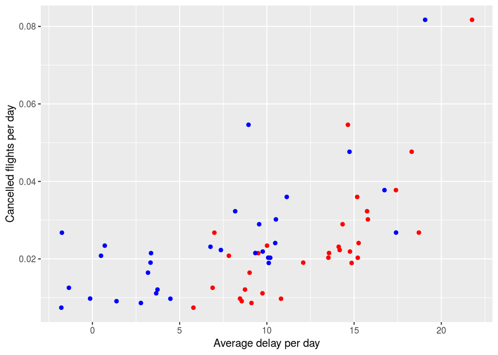

```r
flights %>%
  group_by(day) %>%
  summarise(cancelled = mean(is.na(dep_delay)),
            mean_dep = mean(dep_delay, na.rm = T),
            mean_arr = mean(arr_delay, na.rm = T)) %>%
  ggplot(aes(y = cancelled)) +
  geom_point(aes(x = mean_dep), colour = "red") +
  geom_point(aes(x = mean_arr), colour = "blue") +
  labs(x = "Average delay per day", y = "Cancelled flights per day")
```

5. Which carrier has the worst delays? Challenge: can you disentangle the effects of bad airports vs. bad carriers? Why/why not? (Hint: think about flights %>% group_by(carrier, dest) %>% summarise(n()))

```r
flights %>%
  group_by(carrier) %>%
  summarise(dep_max = max(dep_delay, na.rm = T),
            arr_max = max(arr_delay, na.rm = T)) %>%
  arrange(desc(dep_max, arr_max))
```

```
## # A tibble: 16 x 3
##    carrier dep_max arr_max
##    <chr>     <dbl>   <dbl>
##  1 HA         1301    1272
##  2 MQ         1137    1127
##  3 AA         1014    1007
##  4 DL          960     931
##  5 F9          853     834
##  6 9E          747     744
##  7 VX          653     676
##  8 FL          602     572
##  9 EV          548     577
## 10 B6          502     497
## 11 US          500     492
## 12 UA          483     455
## 13 WN          471     453
## 14 YV          387     381
## 15 AS          225     198
## 16 OO          154     157
```

6. What does the sort argument to count() do. When might you use it? When you want to sort the cases based on the count.